# Exploration

Bethany V Smith

February 20, 2018

```r
library('ggplot2') # visualization
library('ggthemes') # visualization
library('scales') # visualization
library('grid') # visualisation
library('gridExtra') # visualisation
library('corrplot') # visualisation
library('ggfortify') # visualisation
library('dplyr') # data manipulation
library('readr') # data input
library('tibble') # data wrangling
library('stringr') # string manipulation
library('forcats') # factor manipulation
library('mclust') # clustering
train <- read.csv("C:/Users/betha/Desktop/EXST_7152/Group_Project/train.csv")
test <- read.csv("C:/Users/betha/Desktop/EXST_7152/Group_Project/test.csv")
```

```r
glimpse(train)
```

```
## Observations: 4,209
## Variables: 378
## $ ID   <int> 0, 6, 7, 9, 13, 18, 24, 25, 27, 30, 31, 32, 34, 36, 37, 3...
## $ y    <dbl> 130.81, 88.53, 76.26, 80.62, 78.02, 92.93, 128.76, 91.91,...
## $ X0   <fctr> k, k, az, az, az, t, al, o, w, j, h, al, s, al, o, n, al...
## $ X1   <fctr> v, t, w, t, v, b, r, l, s, b, r, r, b, r, s, l, r, aa, c...
## $ X2   <fctr> at, av, n, n, n, e, e, as, as, aq, r, e, ai, e, as, ak, ...
## $ X3   <fctr> a, e, c, f, f, c, f, f, e, c, f, f, c, f, e, f, f, c, c,...
## $ X4   <fctr> d, d, d, d, d, d, d, d, d, d, d, d, d, d, d, d, d, d, d,...
## $ X5   <fctr> u, y, x, x, h, g, f, f, f, f, f, f, f, j, j, j, j, j, j,...
## $ X6   <fctr> j, l, j, l, d, h, h, j, i, a, h, h, g, h, g, d, h, c, d,...
## $ X8   <fctr> o, o, x, e, n, s, s, a, h, e, p, o, m, o, m, k, o, d, e,...
## $ X10  <int> 0, 0, 0, 0, 0, 0, 0, 0, 0, 0, 0, 0, 0, 0, 0, 0, 0, 0, 0, ...
## $ X11  <int> 0, 0, 0, 0, 0, 0, 0, 0, 0, 0, 0, 0, 0, 0, 0, 0, 0, 0, 0, ...
## $ X12  <int> 0, 0, 0, 0, 0, 0, 0, 0, 0, 0, 1, 0, 0, 0, 0, 1, 0, 0, 0, ...
```

[output cut: 365 more lines]

```r
for (i in seq(3,10)){
  print(str_c("Feature", colnames(train)[i], "has these unique values:", sep=" "))
  print(str_sort(unique(train[[i]])))
}
```

```
## [1] "Feature X0 has these unique values:"
##  [1] "a"  "aa" "ab" "ac" "ad" "af" "ai" "aj" "ak" "al" "am" "ao" "ap" "aq"
## [15] "as" "at" "au" "aw" "ax" "ay" "az" "b"  "ba" "bc" "c"  "d"  "e"  "f"
## [29] "g"  "h"  "i"  "j"  "k"  "l"  "m"  "n"  "o"  "q"  "r"  "s"  "t"  "u"
## [43] "v"  "w"  "x"  "y"  "z"
## [1] "Feature X1 has these unique values:"
##  [1] "a"  "aa" "ab" "b"  "c"  "d"  "e"  "f"  "g"  "h"  "i"  "j"  "k"  "l"
## [15] "m"  "n"  "o"  "p"  "q"  "r"  "s"  "t"  "u"  "v"  "w"  "y"  "z"
## [1] "Feature X2 has these unique values:"
##  [1] "a"  "aa" "ac" "ae" "af" "ag" "ah" "ai" "ak" "al" "am" "an" "ao" "ap"
## [15] "aq" "ar" "as" "at" "au" "av" "aw" "ay" "b"  "c"  "d"  "e"  "f"  "g"
## [29] "h"  "i"  "j"  "k"  "l"  "m"  "n"  "o"  "p"  "q"  "r"  "s"  "t"  "x"
## [43] "y"  "z"
## [1] "Feature X3 has these unique values:"
## [1] "a" "b" "c" "d" "e" "f" "g"
## [1] "Feature X4 has these unique values:"
## [1] "a" "b" "c" "d"
## [1] "Feature X5 has these unique values:"
##  [1] "aa" "ab" "ac" "ad" "ae" "af" "ag" "ah" "c"  "d"  "f"  "g"  "h"  "i"
## [15] "j"  "k"  "l"  "m"  "n"  "o"  "p"  "q"  "r"  "s"  "u"  "v"  "w"  "x"
## [29] "y"
## [1] "Feature X6 has these unique values:"
##  [1] "a" "b" "c" "d" "e" "f" "g" "h" "i" "j" "k" "l"
## [1] "Feature X8 has these unique values:"
##  [1] "a" "b" "c" "d" "e" "f" "g" "h" "i" "j" "k" "l" "m" "n" "o" "p" "q"
## [18] "r" "s" "t" "u" "v" "w" "x" "y"
```

Also, all values follow a similar pattern of encoding by one or two letters. We donât know what these letter codes represent, but since we are dealing with car customisation it seems resonable to assume that they encode multiple-choice features for your car specifications. An obvious example would be the colour of the car, which shouldnât have an impact on the testing performance and could therefore correspond to the missing X7 or X9.

(As an aside: I can imagine that one could make an educated guess about the real identity of these multi-level features from the number of the levels and their âpopularityâ in our data, if one were inclined to do so.)

```r
sum(is.na(train))
```

```
## [1] 0
```

There are no missing values in the training data set.

I next want to recode the categorical variables as factors.

```r
train <- train %>%
  mutate_at(vars(X0:X8), funs(factor))
test <- test %>%
  mutate_at(vars(X0:X8), funs(factor))


train_f <- train %>%
  mutate_at(vars(starts_with("X")), funs(factor))
test_f <- test %>%
  mutate_at(vars(starts_with("X")), funs(factor))
```

# 2. Visualizations and Exploratory Analysis

```r
lsize <- length(train)-2
levels <- tibble(
  nr = seq(1,lsize),
  name = "test",
  counts = rep(0,lsize)
)

for (i in seq(3,length(train_f))){
  levels$name[i-2] <- colnames(train_f)[i]
  levels$counts[i-2] <- fct_unique(train_f[[i]]) %>% length()
}

levels %>%
  filter(counts < 2) %>%
  count()
```

```
## # A tibble: 1 x 1
##       n
##   <int>
## 1    12
```

We see from above that there are a total of 12 variables within the dataset without any variation. These classifiers wont contribute any unique variation, or predictive information, for training our classification variables with. Thus, since they arent contributing anything to training, and prediciting our target, we might as well just disregard them.

```r
zero_var_col <- levels %>%
  filter(levels$counts < 2) %>%
  select(name)
print(zero_var_col)
```

```
## # A tibble: 12 x 1
##     name
##    <chr>
##  1   X11
##  2   X93
##  3  X107
##  4  X233
##  5  X235
##  6  X268
##  7  X289
##  8  X290
##  9  X293
## 10  X297
## 11  X330
## 12  X347
```

```r
good_var_col <- levels %>%
  filter(levels$counts > 1) %>%
  select(name)

train <- train %>%
  select_(.dots = c("ID", "y", good_var_col$name))
test <- test %>%
  select_(.dots = c("ID", good_var_col$name))
```

above we remove those features without any unique variation.

Below we look at the correlation between those categorical variables in the training data set. Those variables that were initally loaded as text variables, and that were manipulated above to be factors.

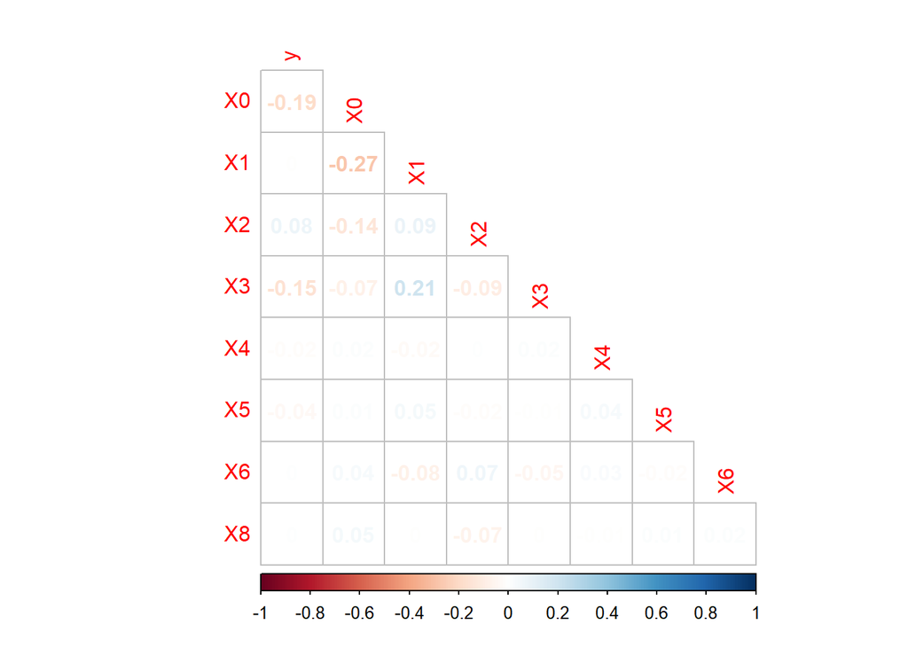

```r
train %>%
  select(y,X0:X8) %>%
  mutate_at(vars(starts_with("X")), funs(as.integer)) %>%
  cor(use="complete.obs", method="pearson") %>%
  corrplot(type="lower", method="number", diag=FALSE)
```

We see from the plot above that those categorical variables with somewhat decent correlation with our target variable y. However, none of these correlations are greater than .5 thus none of the correlations are significant, while others basically have no correlation at all.

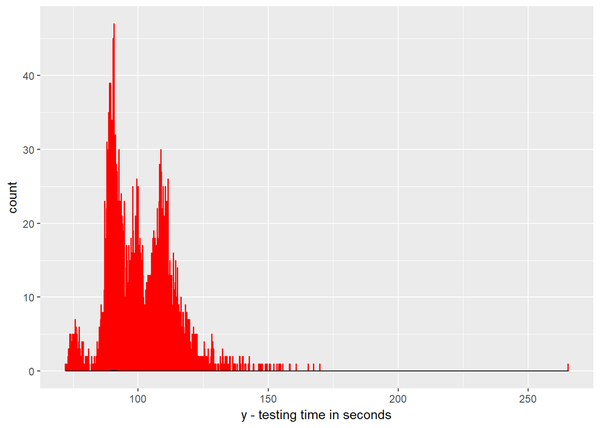

```r
train %>%
  ggplot(aes(y)) +
  geom_histogram(colour="red", bins = length(train$y)/3) +
  geom_density() +
  labs(x = "y - testing time in seconds")
```